# Data Analyst Project

Jihan Farah S

2022-10-23

# Cyclistic Bike-Sharing Analysis

## Overview

This project is part of Google Data Analytics Course on Coursera.

In 2016, Cyclistic launched a successful bike-sharing offering. Since then, the program has grown to a fleet of 5,824 bikes that are geo-tracked and locked into a network of 692 stations across Chicago. Bikes can be accessed from one station and returned to another at any time in the system.

To date, Cyclistic’s marketing strategy has relied on efforts to build general awareness and attract a broad consumer segment. One approach that helps make this happen is price flexibility: one-way tickets, full-day passes, and annual memberships. Customers who purchase a one-way ticket or a full day ticket are referred to as casual riders. Customers who purchase an annual membership are Cyclistic members. Therefore, the marketing analyst team needs to better understand the differences between annual members and regular riders in this month.

## Dataset Preview

For this project, we will use the data for September 2022 [here](https://divvy-tripdata.s3.amazonaws.com/index.html).

This dataset is in the form of CSV (comma-separated value) with 701,339 rows of data. The field in data included:

1. ride_id
2. rideable_type
3. started_at
4. ended_at
5. start_station_name
6. start_station_id
7. end_station_name
8. end_station_id
9. start_lat
10. start_lng
11. end_lat
12. end_lng
13. member_casual

## Steps

1. Import data.
2. Clean and add data to prepare for analysis.
3. Perform a descriptive analysis.

## Import Data

```r
library("readr")
library("dplyr")

#Importing data
divvy_202209 <- read_csv("~/divvy-tripdata/202209-divvy-publictripdata.csv")

#Checking data dimension
dim(divvy_202209)
```

```
## [1] 701339     13
```

```r
#Checking columns names
colnames(divvy_202209)
```

```
##  [1] "ride_id"            "rideable_type"      "started_at"
##  [4] "ended_at"           "start_station_name" "start_station_id"
##  [7] "end_station_name"   "end_station_id"     "start_lat"
## [10] "start_lng"          "end_lat"            "end_lng"
## [13] "member_casual"
```

## Data Cleaning and Preparation

We will analyze the behavior of member and casual users, so we only need ride_id, rideable_type, started_at, ended_at, and member_casual.

```r
#Selecting columns
divvy_202209 <- divvy_202209 %>%
  select(c(ride_id, rideable_type, started_at,ended_at,member_casual))

head(divvy_202209)
```

```
## # A tibble: 6 × 5
##   ride_id          rideable_type started_at          ended_at            membe…¹
##   <chr>            <chr>         <dttm>              <dttm>              <chr>
## 1 5156990AC19CA285 electric_bike 2022-09-01 08:36:22 2022-09-01 08:39:05 casual
## 2 E12D4A16BF51C274 electric_bike 2022-09-01 17:11:29 2022-09-01 17:14:45 casual
## 3 A02B53CD7DB72DD7 electric_bike 2022-09-01 17:15:50 2022-09-01 17:16:12 casual
## 4 C82E05FEE872DF11 electric_bike 2022-09-01 09:00:28 2022-09-01 09:10:32 casual
## 5 4DEEB4550A266AE1 electric_bike 2022-09-01 07:30:11 2022-09-01 07:32:36 casual
## 6 B1721F8C7C3AC6BF electric_bike 2022-09-01 12:04:25 2022-09-01 12:21:08 casual
## # … with abbreviated variable name ¹member_casual
```

We will analyze the ride length of users, so we will make new column that shows the length of ride in minutes. We will count the difference between start and end time of ride.

```r
#Make new column for ride length
divvy_202209$ride_length <- difftime(divvy_202209$ended_at,divvy_202209$started_at)
divvy_202209$ride_length <- as.double(divvy_202209$ride_length)
```

Then, we remove the row with negative values of ride length.

```r
#Remove the row with negative value of ride length
divvy_202209_v2 <- divvy_202209[!divvy_202209$ride_length<0,]
```

We will analyze bike usage for each day, making new columns for the started day, ended day, and each day in a week.

```r
#Make new column for bike usage in start_date, end_date
divvy_202209_v2$started_date <- as.Date(divvy_202209_v2$started_at)
divvy_202209_v2$ended_date <- as.Date(divvy_202209_v2$ended_at)
divvy_202209_v2$Day_of_week <- format(as.Date(divvy_202209_v2$started_date), "%A")
```

We will check data summary of ride length to see any outliers.

```r
#Summary of ride length
summary(divvy_202209_v2$ride_length)
```

```
##    Min. 1st Qu.  Median    Mean 3rd Qu.    Max.
##       0     353     613    1160    1075 1661854
```

We get that the minimum ride length is 0 sec, the 1st quantile is 353 secs, the median is 613 secs, the 3rd quantile is 1075 secs, the maximum ride length is 1661854 secs, and the mean is 1160 secs. From the summary, we get the possibilities that the usage of bikes can be more than one day. It can affect our analysis if we want to check the average ride length for each day.

Furthermore, we need to filter the data to analyze the ride that starts and ends on the same day.

```r
#Filtering the data
divvy_202209_v3 <- divvy_202209_v2 %>%
  filter(started_date == ended_date)
```

We check the summary from the new dataset.

```r
#Summary of ride length in new dataset
summary(divvy_202209_v3$ride_length)
```

```
##    Min. 1st Qu.  Median    Mean 3rd Qu.    Max.
##     0.0   352.0   610.0   917.7  1068.0 77295.0
```

## Analyzing Data

We will compare the mean, minimum, maximum, and median of member and casual users in ride length for the same-day trip.

```r
#Compare member and casual user in ride length
aggregate(divvy_202209_v3$ride_length ~ divvy_202209_v3$member_casual, FUN = mean)
```

```
##   divvy_202209_v3$member_casual divvy_202209_v3$ride_length
## 1                        casual                    1154.857
## 2                        member                     744.738
```

```r
aggregate(divvy_202209_v3$ride_length ~ divvy_202209_v3$member_casual, FUN = min)
```

```
##   divvy_202209_v3$member_casual divvy_202209_v3$ride_length
## 1                        casual                           0
## 2                        member                           0
```

```r
aggregate(divvy_202209_v3$ride_length ~ divvy_202209_v3$member_casual, FUN = max)
```

```
##   divvy_202209_v3$member_casual divvy_202209_v3$ride_length
## 1                        casual                       77295
## 2                        member                       69947
```

```r
aggregate(divvy_202209_v3$ride_length ~ divvy_202209_v3$member_casual, FUN = median)
```

```
##   divvy_202209_v3$member_casual divvy_202209_v3$ride_length
## 1                        casual                         717
## 2                        member                         545
```

From the data, we can see that the mean ride lengths for the same-day trip are 1154.857 secs for casual users and 744.738 for member users.

The minimum ride length for both users is 0 seconds and the maximum ride lengths for casual and member users are 77295 secs and 69947 secs, consecutively.

The median ride length for casual and member users is 717 secs and 545 secs.

Then, we compare the total of members and casual users based on rideable type.

```r
#Compare member and casual user with rideable type
library("janitor")
divvy_202209_v3 %>%
  tabyl(rideable_type,member_casual) %>%
  adorn_totals()
```

```
##  rideable_type casual member
##   classic_bike 104229 200024
##    docked_bike  19302      0
##  electric_bike 170453 203226
##          Total 293984 403250
```

We can see that there are no member users who use docked bike. The number of member users who use classic bike and electric bike are larger than casual users. We also can see the total of member users is larger than casual users.

Then, we compare the total of member and casual user based on ride length each day.

```r
#Compare member and casual user in ride length each day
aggregate(divvy_202209_v3$ride_length ~ divvy_202209_v3$member_casual + divvy_202209_v3$Day_of_week, FUN =mean)
```

```
##    divvy_202209_v3$member_casual divvy_202209_v3$Day_of_week
## 1                         casual                      Friday
## 2                         member                      Friday
## 3                         casual                      Monday
## 4                         member                      Monday
## 5                         casual                    Saturday
## 6                         member                    Saturday
## 7                         casual                      Sunday
## 8                         member                      Sunday
## 9                         casual                    Thursday
## 10                        member                    Thursday
## 11                        casual                     Tuesday
## 12                        member                     Tuesday
## 13                        casual                   Wednesday
## 14                        member                   Wednesday
##    divvy_202209_v3$ride_length
## 1                    1109.3511
## 2                     741.6354
## 3                    1207.7829
## 4                     725.1812
## 5                    1366.1980
## 6                     837.9411
## 7                    1278.5371
## 8                     811.2828
## 9                     991.7599
## 10                    718.0479
## 11                    995.5650
## 12                    703.1246
## 13                   1010.0882
## 14                    715.1021
```

The days in the output are not in order, so we need to rearrange it first.

```r
#Ordering day
divvy_202209_v3$Day_of_week <- ordered(divvy_202209_v3$Day_of_week, levels=c("Monday", "Tuesday", "Wednesday", "Thursday","Friday","Saturday","Sunday"))
```

Then we can check the data with new order.

```r
#Compare member and casual user in ride length each day
aggregate(divvy_202209_v3$ride_length ~ divvy_202209_v3$member_casual + divvy_202209_v3$Day_of_week, FUN =mean)
```

```
##    divvy_202209_v3$member_casual divvy_202209_v3$Day_of_week
## 1                         casual                      Monday
## 2                         member                      Monday
## 3                         casual                     Tuesday
## 4                         member                     Tuesday
## 5                         casual                   Wednesday
## 6                         member                   Wednesday
## 7                         casual                    Thursday
## 8                         member                    Thursday
## 9                         casual                      Friday
## 10                        member                      Friday
## 11                        casual                    Saturday
## 12                        member                    Saturday
## 13                        casual                      Sunday
## 14                        member                      Sunday
##    divvy_202209_v3$ride_length
## 1                    1207.7829
## 2                     725.1812
## 3                     995.5650
## 4                     703.1246
## 5                    1010.0882
## 6                     715.1021
## 7                     991.7599
## 8                     718.0479
## 9                    1109.3511
## 10                    741.6354
## 11                   1366.1980
## 12                    837.9411
## 13                   1278.5371
## 14                    811.2828
```

For make the data easier to see, we will make the visualization.

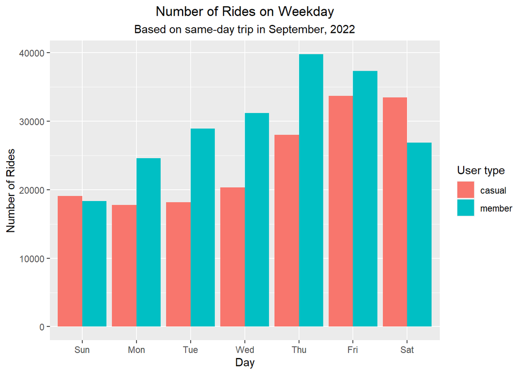

```r
library("ggplot2")
library("lubridate")

#Analyze number of rides on weekday by user type
divvy_202209_v3 %>%
  mutate(weekday = lubridate::wday(started_date, label = TRUE)) %>%  #creates weekday field using wday()
  group_by(member_casual, weekday, rideable_type) %>%  #groups by usertype and weekday'
  summarise(number_of_rides = n(), #calculates the number of rides and average duration
            average_duration = mean(ride_length)) %>% # calculates the average duration
  arrange(member_casual, weekday) %>% # sorts
  ggplot(aes(x = weekday, y = number_of_rides, fill = member_casual)) +
  geom_col(position = "dodge") +
  labs(title = "Number of Rides on Weekday", subtitle = "Based on same-day trip in September, 2022", x="Day", y="Number of Rides", fill="User type") +
  theme(plot.title =element_text(hjust = 0.5), plot.subtitle =element_text(hjust = 0.5) )
```

From the graphic, we can see that the number of rides for member users is higher than for casual users, except on Saturday and Sunday.

The highest number of rides by member users is on Thursday, and the highest number of rides by casual users is on Friday and Saturday.

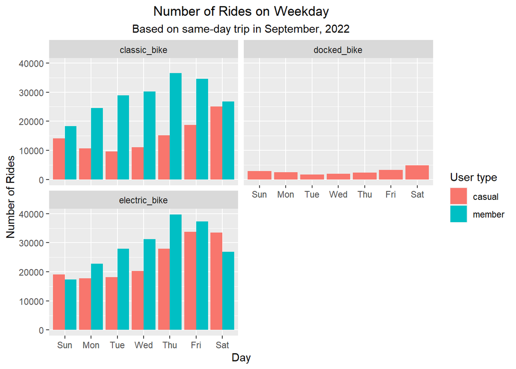

```r
#Analyze number of rides on weekday by user type and bike type
divvy_202209_v3 %>%
  mutate(weekday = lubridate::wday(started_date, label = TRUE)) %>%  #creates weekday field using wday()
  group_by(member_casual, weekday, rideable_type) %>%  #groups by usertype and weekday'
  summarise(number_of_rides = n(), #calculates the number of rides and average duration
            average_duration = mean(ride_length)) %>% # calculates the average duration
  arrange(member_casual, weekday) %>% # sorts
  ggplot(aes(x = weekday, y = number_of_rides, fill = member_casual)) +
  geom_col(position = "dodge") +
  labs(title = "Number of Rides on Weekday", subtitle = "Based on same-day trip in September, 2022", x="Day", y="Number of Rides", fill="User type") +
  theme(plot.title =element_text(hjust = 0.5),plot.subtitle = element_text(hjust = 0.5)) +
  facet_wrap("rideable_type",ncol=2,nrow =2)
```

From the graph, we can see the highest number of rides by casual users and member users with the classic bike are on Saturday and Thursday, consecutively.

The highest number of rides by casual users and member users with electric bikes are on Friday and Thursday, consecutively.

The highest number of rides by casual users with the docked bike is on Saturday.

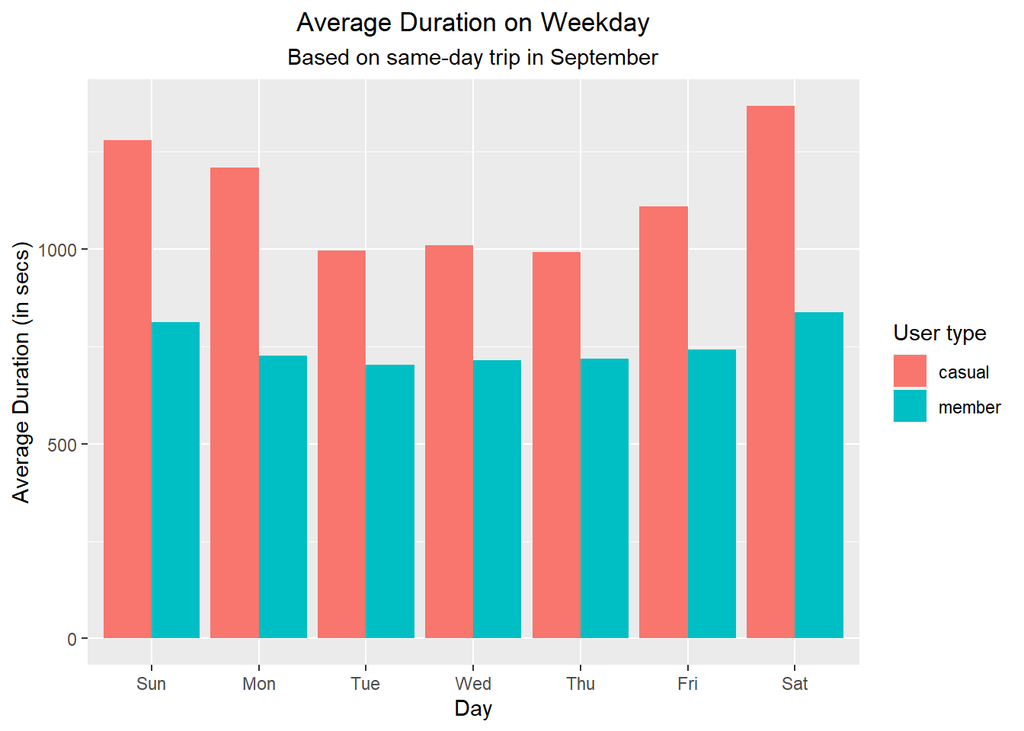

```r
#Analyze average duration on weekday by user type
divvy_202209_v3 %>%
  mutate(weekday = lubridate::wday(started_date, label = TRUE)) %>%  #creates weekday field using wday()
  group_by(member_casual, weekday) %>%  #groups by usertype and weekday'
  summarise(number_of_rides = n(), #calculates the number of rides and average duration
            average_duration = mean(ride_length)) %>% # calculates the average duration
  arrange(member_casual, weekday) %>% # sorts
  ggplot(aes(x = weekday, y = average_duration, fill = member_casual)) +
  geom_col(position = "dodge") +
  labs(title = "Average Duration on Weekday",subtitle = "Based on same-day trip in September", x="Day", y="Average Duration (in secs)", fill="User type") +
  theme(plot.title = element_text(hjust = 0.5), plot.subtitle = element_text(hjust = 0.5))
```

We can see from the graphic that casual users have a longer average trip duration per day than member users, with the highest being on Saturdays. The highest average trip duration for member users is on Saturday and Sunday.

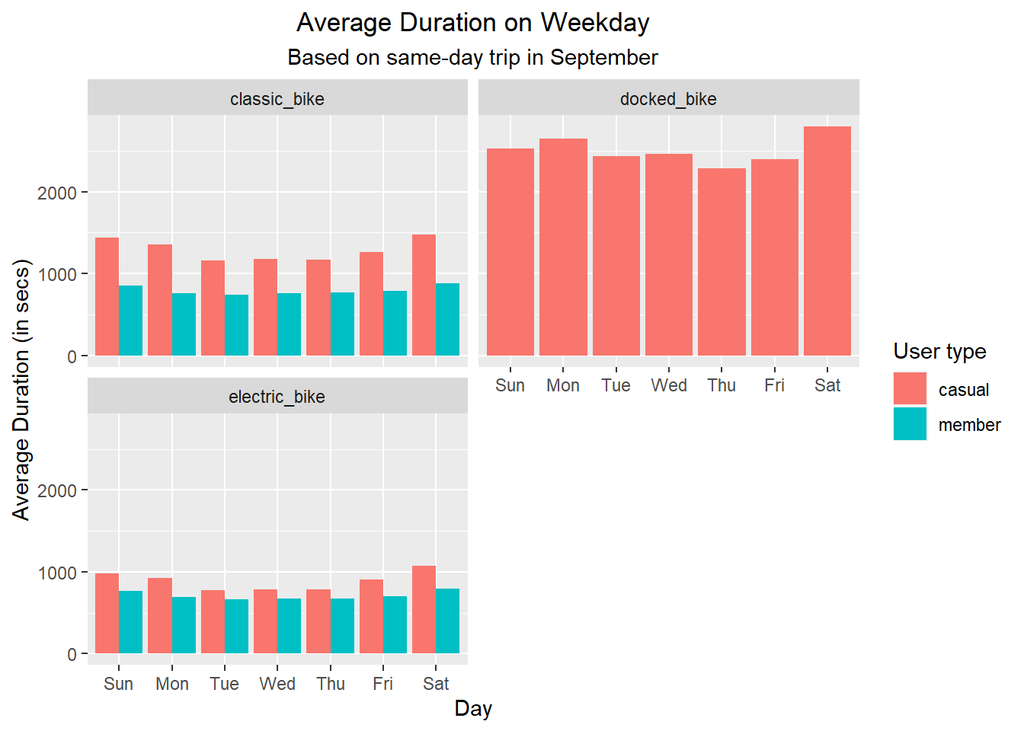

```r
#Analyze average duration on weekday by user type
divvy_202209_v3 %>%
  mutate(weekday = lubridate::wday(started_date, label = TRUE)) %>%  #creates weekday field using wday()
  group_by(member_casual, weekday, rideable_type) %>%  #groups by usertype and weekday'
  summarise(number_of_rides = n(), #calculates the number of rides and average duration
            average_duration = mean(ride_length)) %>% # calculates the average duration
  arrange(member_casual, weekday) %>% # sorts
  ggplot(aes(x = weekday, y = average_duration, fill = member_casual)) +
  geom_col(position = "dodge") +
  labs(title = "Average Duration on Weekday",subtitle = "Based on same-day trip in September", x="Day", y="Average Duration (in secs)", fill="User type") +
  theme(plot.title =element_text(hjust = 0.5), plot.subtitle = element_text(hjust = 0.5)) +
  facet_wrap("rideable_type",ncol=2,nrow =2)
```

We can see the average trip durations of the docked bike are higher than other types of bikes, with the highest being on Saturday.

For the classic bike, the highest trip average durations are by casual users on Saturday and Sunday. Then, the highest trip average durations for the classic bike by member users are also on Saturday and Sunday.

For the electric bike, the highest trip average durations are by casual users on Saturday. Then, the highest trip average durations for the electric bike by member users are on Saturday and Sunday.